# Machine-Learning-vol.07-ロジスティック回帰ml7_001ml7_04ml7_05ml7_122不備

### 7.4.2 データの可視化

散布図行列を出力して､**分類に利用する説明変数にあたりをつけていきます**｡ちなみに､今回は以下の4つの特徴量をピックアップしました｡可視化のために､**この中から2つの変数をピックアップして利用します**｡

- worst perimeter
- worst concave points
- worst radius
- mean concave points

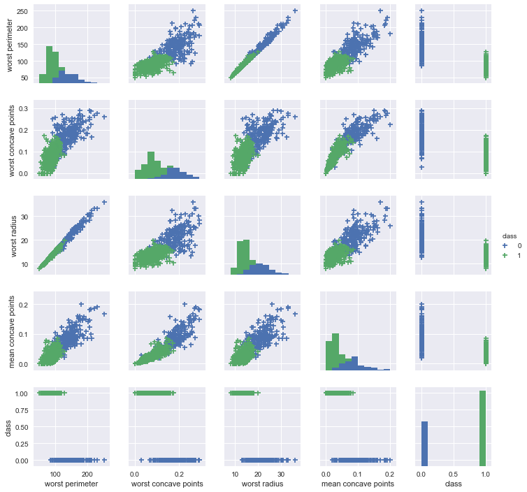

```python
# 散布図行列を出力
df_pickup = df.loc[:, ['worst perimeter', 'worst concave points', 'worst radius', 'mean concave points', 'class']]
sns.pairplot(df_pickup, size=2.0, hue='class', markers='+')
plt.show()
```

今回はworst perimeterとmean concave pointsのつの特徴量を利用して分類します｡

## 7.5 ロジスティック回帰の実装

### 7.5.1 学習の実行

```python
# 説明変数と目的変数を指定
X = df.loc[:, ['worst perimeter', 'mean concave points']].values
y = df.loc[:, ['class']].values
# scikit-learnの仕様に合わせて､一列のベクトルに変換
y = y.reshape(-1)
```

```python
# データの標準化
from sklearn.preprocessing import StandardScaler
scaler = StandardScaler()
scaler.fit(X)
X_std = scaler.transform(X)
```

```python
# データセットの分割
from sklearn.model_selection import train_test_split
X_train, X_test, y_train, y_test = train_test_split(X_std, y, test_size=0.3, random_state=0)
```

#### ロジスティック回帰の学習

ロジスティック回帰は､**sklearn.linear_model**の**LogisticRegression**クラスを利用して実行できます｡**逆正則化パラメータ $C$** は､デフォルトで1.0に設定されています｡

```python
# ロジスティック回帰の実行
from sklearn.linear_model import LogisticRegression
lr = LogisticRegression(C=1.0)
lr.fit(X_train, y_train)
```

```
LogisticRegression(C=1.0, class_weight=None, dual=False, fit_intercept=True,
          intercept_scaling=1, max_iter=100, multi_class='ovr', n_jobs=1,
          penalty='l2', random_state=None, solver='liblinear', tol=0.0001,
          verbose=0, warm_start=False)
```

### 7.5.2 学習結果の評価

- 決定境界
- 正答率

#### 決定境界の出力

```python
# ２次元データの決定曲線をプロットする関数
def plot_decision_regions(X, y, classifier, resolution=0.02):
    from matplotlib.colors import ListedColormap
    markers = ("s", "x", "o", "^", "v")
    colors = ("red", "blue", "lightgreen", "gray", "cyan")
    cmap = ListedColormap(colors[:len(np.unique(y))])

    x1_min, x1_max = X[:, 0].min()-1 , X[:, 0].max() +1
    x2_min, x2_max = X[:, 1].min()-1 , X[:, 1].max() +1

    xx1, xx2 = np.meshgrid(np.arange(x1_min, x1_max, resolution), np.arange(x2_min, x2_max, resolution))
    Z = classifier.predict(np.array([xx1.ravel(), xx2.ravel()]).T)
    Z = Z.reshape(xx1.shape)
    plt.contourf(xx1, xx2, Z, alpha=0.4, cmap=cmap)

    plt.xlim(xx1.min(), xx1.max())
    plt.ylim(xx2.min(), xx2.max())

    for idx, cl in enumerate(np.unique(y)):
        plt.scatter(x=X[y == cl, 0], y=X[y == cl, 1], alpha=0.8, c=cmap(idx),marker=markers[idx], label=cl)
```

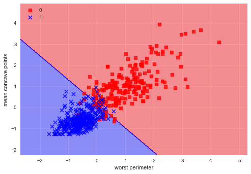

```python
# 決定境界を出力
plot_decision_regions(X_std, y, lr)
plt.xlabel("worst perimeter")
plt.ylabel("mean concave points")
plt.legend(loc = "upper left")
plt.show()
```

決定境界のプロットより､一応の分類性能があることが確認できます｡

#### 正答率を出力

```python
# 正答率を出力
print('train acc: %.3f' % lr.score(X_train, y_train))
print('test acc: %.3f' % lr.score(X_test, y_test))
```

```
train acc: 0.930
test acc: 0.924
```

testの正答率は92.4%となりました｡また､trainの場合との比較から､過学習を起こしていないことが確認できます｡

### 7.5.3 学習済みモデルの利用

最尤推定により､ロジスティック回帰のモデルを正常に学習させることができました｡それでは､最後に**このモデルを実際の検査に利用することを想定して**､testデータのサンプル（それぞれの患者の検査結果）に対して予測をさせてみましょう｡

[figure not shown]

まず､testデータのサンプル数を確認します｡すべてで171サンプルあるので､indexは0〜170の範囲で指定できます｡

```python
# testデータのサンプル数を出力
len(y_test)
```

```
171
```

```python
# testデータのインデックスを指定（0<=index<=170）
index = 0
```

まず､**予測確率**を出力します｡

```python
# 予測確率を出力
# [悪性である確率, 良性である確率]
lr.predict_proba(X_test[index].reshape(1, -1))
```

```
array([[ 0.90416777,  0.09583223]])
```

```python
# 正解と予測のクラスラベルを出力
print('answer : %d' % y_test[index])
print('predict: %d' % lr.predict(X_test[index].reshape(1, -1)))
```

```
answer : 0
predict: 0
```

予測の結果､index=0に対応する患者は**乳がんの発症確率が90%となりました**｡結果的には､**｢発症していそうか､いなさそうか｣**を問えば､**｢発症していそう｣**ということになります｡ただし､確率は51%ではなく90%ですので､**｢発症はほぼ確実にしているでしょう｣**という結論になります｡となれば､**一刻も早く精密検査を受け､早期の治療を行うべきでしょう**｡

[figure not shown]

監修: 東京女子大学情報処理センター 浅川伸一